# 09_model_interpretation

```python
import pandas as pd
df = pd.read_csv("C:/Users/Tanisha/Desktop/ai4i2020.csv")
```

```python
X = df[['Air temperature [K]',
        'Process temperature [K]',
        'Rotational speed [rpm]',
        'Torque [Nm]',
        'Tool wear [min]']]

y = df['Machine failure']
```

```python
from imblearn.over_sampling import SMOTE

smote = SMOTE(random_state=42)

X_smote, y_smote = smote.fit_resample(X, y)

print("After SMOTE:")
print(y_smote.value_counts())
```

```
After SMOTE:
Machine failure
0    9661
1    9661
Name: count, dtype: int64
```

```python
from sklearn.model_selection import train_test_split

X_train_s, X_test_s, y_train_s, y_test_s = train_test_split(
    X_smote, y_smote, test_size=0.2, random_state=42
)
```

```python
from sklearn.ensemble import RandomForestClassifier

rf_smote = RandomForestClassifier(random_state=42)

rf_smote.fit(X_train_s, y_train_s)

y_pred_smote = rf_smote.predict(X_test_s)
```

```python
y_pred_smote = rf_smote.predict(X_test_s)
```

```python
from sklearn.metrics import confusion_matrix

cm = confusion_matrix(y_test_s, y_pred_smote)

print(cm)
```

```
[[1876   58]
 [  27 1904]]
```

## Task 1

## Shap analysis

```python
!pip install shap
```

[figure not shown]

```python
import shap

# Create explainer
explainer = shap.TreeExplainer(rf_smote)

# Calculate SHAP values
shap_values = explainer.shap_values(X_test_s)

# Summary plot
shap.summary_plot(shap_values, X_test_s)
```

```python
print(shap_values)
```

[output not shown]

## Task 2

## Feature importance visualization

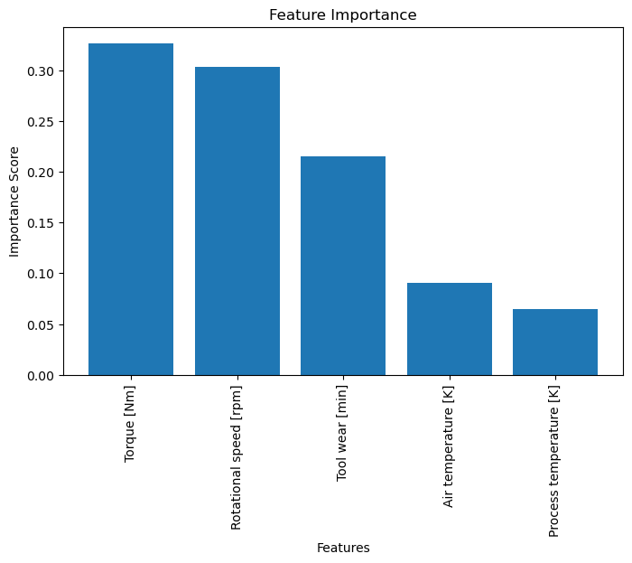

```python
import matplotlib.pyplot as plt

# Get feature importance from the model
importances = rf_smote.feature_importances_

# Create dataframe
feature_importance = pd.DataFrame({
    'Feature': X_train_s.columns,
    'Importance': importances
})

# Sort features
feature_importance = feature_importance.sort_values(by='Importance', ascending=False)

# Plot
plt.figure(figsize=(8,5))
plt.bar(feature_importance['Feature'], feature_importance['Importance'])
plt.xticks(rotation=90)
plt.title("Feature Importance")
plt.xlabel("Features")
plt.ylabel("Importance Score")
plt.show()
```

## Task 3

## Stability analysis (train/test shift)

```
                          Train Mean    Test Mean
Air temperature [K]       300.455960   300.453516
Process temperature [K]   310.153077   310.159186
Rotational speed [rpm]   1516.134114  1515.592497
Torque [Nm]                44.917457    44.921684
Tool wear [min]           124.749240   125.898318
```

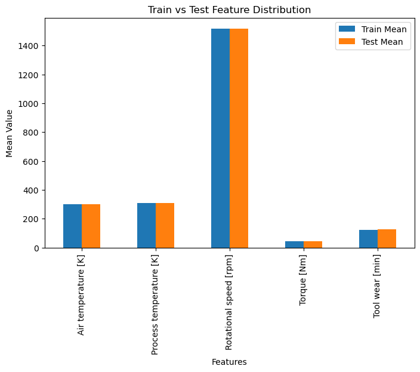

```python
import matplotlib.pyplot as plt

# Compare mean values of features in train and test
train_mean = X_train_s.mean()
test_mean = X_test_s.mean()

# Create dataframe
stability_df = pd.DataFrame({
    "Train Mean": train_mean,
    "Test Mean": test_mean
})

print(stability_df)

# Plot comparison
stability_df.plot(kind='bar', figsize=(8,5))
plt.title("Train vs Test Feature Distribution")
plt.xlabel("Features")
plt.ylabel("Mean Value")
plt.xticks(rotation=90)
plt.show()
```

## Task 4 : Create

## 1) Model performance dashboard (basic)

```
      Metric     Score
0   Accuracy  0.978008
1  Precision  0.970438
2     Recall  0.986018
3   F1 Score  0.978166
```

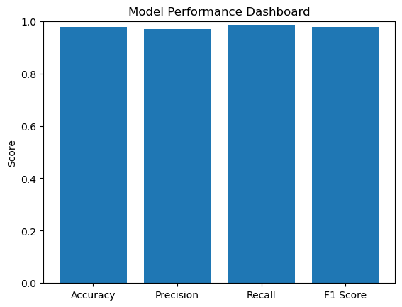

```python
from sklearn.metrics import accuracy_score, precision_score, recall_score, f1_score
import pandas as pd
import matplotlib.pyplot as plt

# Predictions
y_pred = rf_smote.predict(X_test_s)

# Calculate metrics
accuracy = accuracy_score(y_test_s, y_pred)
precision = precision_score(y_test_s, y_pred)
recall = recall_score(y_test_s, y_pred)
f1 = f1_score(y_test_s, y_pred)

# Create dataframe
metrics = pd.DataFrame({
    "Metric": ["Accuracy", "Precision", "Recall", "F1 Score"],
    "Score": [accuracy, precision, recall, f1]
})

print(metrics)

# Plot dashboard
plt.bar(metrics["Metric"], metrics["Score"])
plt.title("Model Performance Dashboard")
plt.ylabel("Score")
plt.ylim(0,1)
plt.show()
```

## Task 6

## 1) Monitoring metrics

#### To ensure that the model continues to perform well after deployment, several performance metrics should be monitored regularly. Important metrics include accuracy, precision, recall, and F1-score. These metrics help evaluate how well the model predicts machine failures. Monitoring these metrics over time can help detect performance degradation and ensure the reliability of the predictive maintenance system.

## 2) Retraining schedule

#### Machine learning models may lose accuracy over time as new data becomes available or machine conditions change. Therefore, it is recommended to retrain the model periodically using updated data. A retraining schedule of every 3–6 months is suggested. Retraining can also be triggered if a significant drop in model performance is observed.

## 3) Data drift checks

#### Data drift occurs when the statistical properties of incoming data change compared to the training data. This can negatively impact model performance. To prevent this, regular data drift checks should be performed by comparing the distribution of new data with the original training dataset. If significant drift is detected, the model should be retrained with updated data to maintain accurate predictions.